# Integrative analysis of the effects of cellular and organismal perturbations on the transcriptomes of hippocampal subfields

June 15, 2017

## Advances in hippocampal neurogenomics

Gene expression studies at the level of single neurons may be especially important for understanding nervous system structure and function because of neuron-specific functionality and plasticity.

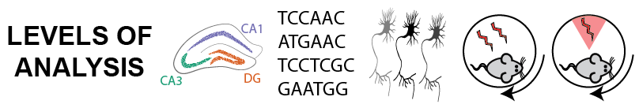

## Objective

Here, we examine the effect of cellular dissociation on gene expression in the mouse hippocampus. We also determine to which extent such changes might confound studies on the behavioral and physiological functions of hippocampus.

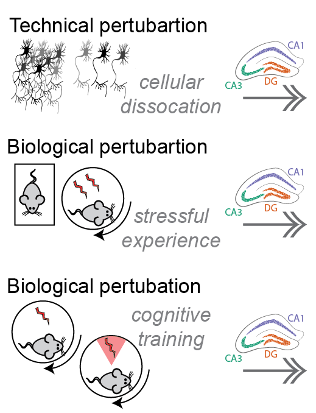

## Materials & Methods

We processed dentate gyrus (DG), CA3, and CA1 hippocampus subfields tissue samples for RNA sequencing to quantify sub-field specific gene expression. This is a rough overview of the workflow.

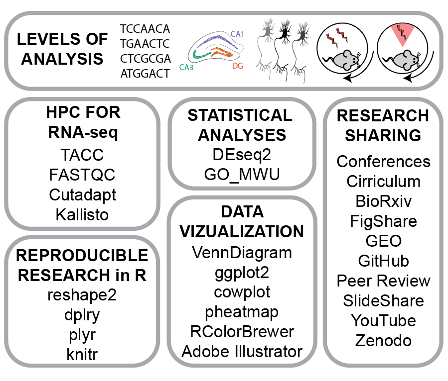

## Technical: Cellular dissociation

We find that 1% of the hippocampal transcriptome responds to the process of cellular dissociation.

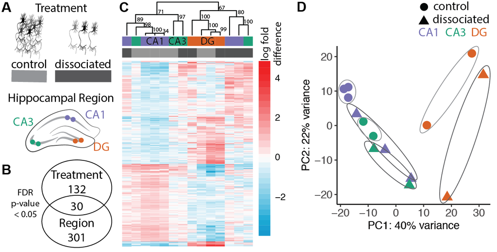

The genomic plasticity is specific to these molecular processes.

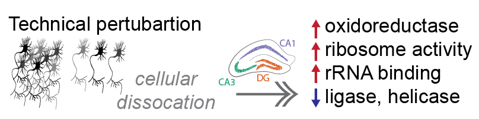

## Biological: Stress

No genes or molecular pathways were differntially expressed between samples from non-stress and stressedmice.

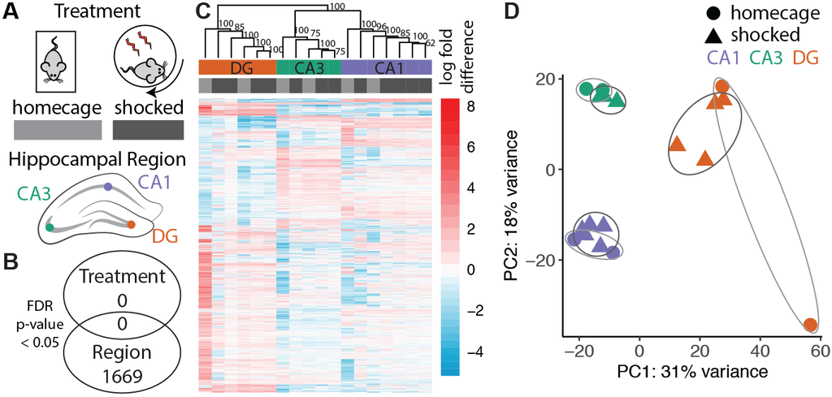

The hippocampus does not exhbit genomic plasticity in response to sress.

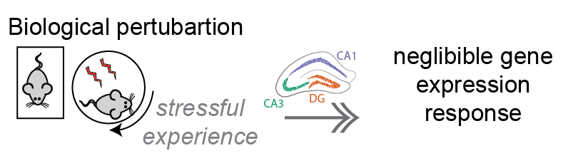

## Biological: Cognitive training

Cognitive training does incuce genomic plastcity.

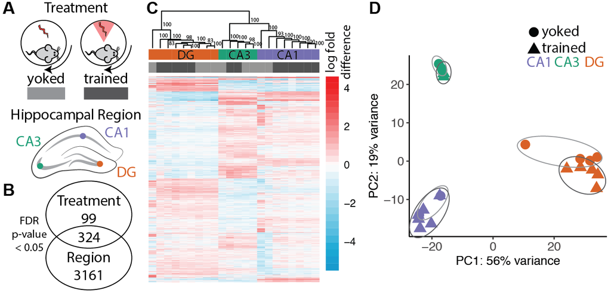

The genomic plasticity is specific to these molecular processes.

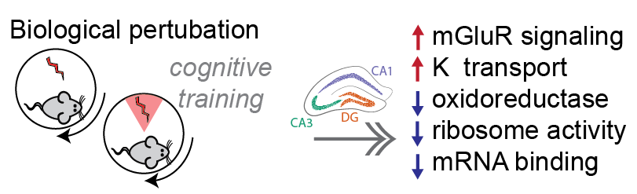

## Integrative analysis

There was some overlap in the genomic response to different manipulation. These findings of the concordant and discordant effects should inform the design of future neural transcriptome studies.

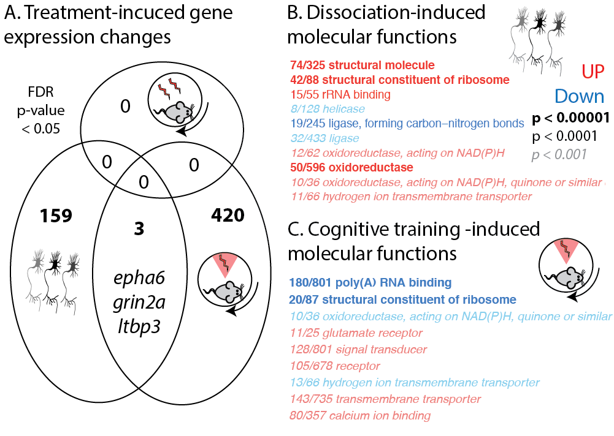

## Meta analysis

We identified robust subfield-specific gene expression patterns that are consistent with those identified stored in public databases and repositories.

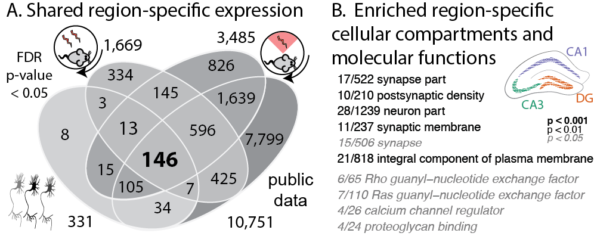

## Conclusion

By determining the extent to which the process of cellular disassociation and stressful experience impacts our ability to correctly detect cognitive perturbations to gene expression, this study sets a baseline for future studies aimed at understanding molecular function in hippocampus and behavior.

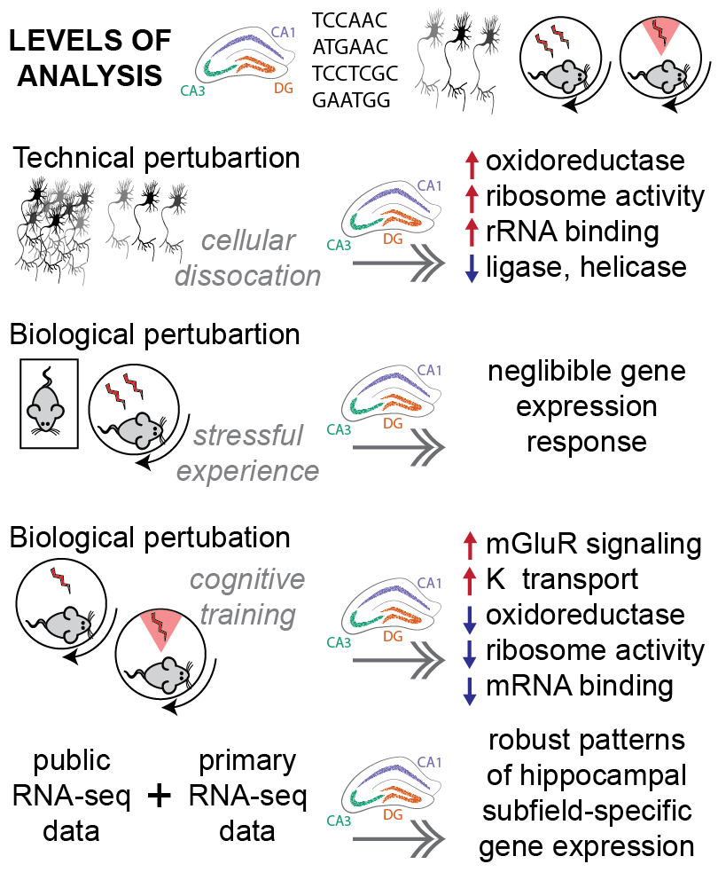